# Introduction:

Health insurance is an essential tool for protecting individuals from the financial burden of medical expenses. However, the cost of insurance—particularly the premiums and charges—can vary significantly between individuals. These differences are not arbitrary; they often stem from measurable factors such as age, body composition, lifestyle habits, and geographic location.

This project analyzes a dataset of individual health insurance records to identify the factors that most influence medical charges. By examining demographic variables (age, sex, region) and health-related attributes (BMI, smoking status, number of dependents), we aim to uncover trends and patterns that can support more accurate cost predictions.

**Goals of the Analysis**:

1. Segment individuals based on age, BMI, and smoking habits.
2. Compare how different segments vary in average medical charges.
3. Identify high-risk profiles that tend to incur higher healthcare costs.
4. Present findings through clear, insightful visualizations to simulate real-world business insight generation.

Through this analysis, we demonstrate how data can inform decision-making for insurers, healthcare providers, and policymakers in understanding cost drivers and optimizing risk management strategies.

# The Dataset

The dataset is obtained from Kaggle. The dataset consist of 7 columns:

**age**: age of primary beneficiary

**sex**: insurance contractor gender, male or female

**bmi**: body mass index, providing an understanding of body, weights that are relatively high or low relative to height, objective index of body weight (kg / m ^ 2) using the ratio of height to weight

**children**: number of children covered by health insurance / number of dependents

**smoker**: is the beneficiary smoking? yes or no

**region**: the beneficiary's residential area in the US; northeast, southeast, southwest, northwest.

**charges**: individual medical costs billed by health insurance, in USD

# Importing Necessary and Exploring Data

```python
#Importing necessary modules
import pandas as pd
import matplotlib.pyplot as plt
import numpy as np
import seaborn as sns

import warnings
warnings.filterwarnings('ignore')
```

```python
#loading and exploring the data set
df = pd.read_csv('insurance.csv')
df
```

|  | age | sex | bmi | children | smoker | region | charges |
| --- | --- | --- | --- | --- | --- | --- | --- |
| 0 | 19 | female | 27.900 | 0 | yes | southwest | 16884.92400 |
| 1 | 18 | male | 33.770 | 1 | no | southeast | 1725.55230 |
| 2 | 28 | male | 33.000 | 3 | no | southeast | 4449.46200 |
| 3 | 33 | male | 22.705 | 0 | no | northwest | 21984.47061 |
| 4 | 32 | male | 28.880 | 0 | no | northwest | 3866.85520 |
| ... | ... | ... | ... | ... | ... | ... | ... |
| 1333 | 50 | male | 30.970 | 3 | no | northwest | 10600.54830 |
| 1334 | 18 | female | 31.920 | 0 | no | northeast | 2205.98080 |
| 1335 | 18 | female | 36.850 | 0 | no | southeast | 1629.83350 |
| 1336 | 21 | female | 25.800 | 0 | no | southwest | 2007.94500 |
| 1337 | 61 | female | 29.070 | 0 | yes | northwest | 29141.36030 |

1338 rows × 7 columns

```python
#No of rows and columns

print("no of rows:",df.shape[0] ," ","no_of_columns:",df.shape[1] )



# summary of data frame
print(df.info())
```

```
no of rows: 1338   no_of_columns: 7
<class 'pandas.core.frame.DataFrame'>
RangeIndex: 1338 entries, 0 to 1337
Data columns (total 7 columns):
 #   Column    Non-Null Count  Dtype
---  ------    --------------  -----
 0   age       1338 non-null   int64
 1   sex       1338 non-null   object
 2   bmi       1338 non-null   float64
 3   children  1338 non-null   int64
 4   smoker    1338 non-null   object
 5   region    1338 non-null   object
 6   charges   1338 non-null   float64
dtypes: float64(2), int64(2), object(3)
memory usage: 73.3+ KB
None
```

There are 1338 data in all columns. Since the number is same across all columns, the are no missing data in the dataset

```python
#Description of data set

df.describe()
```

|  | age | bmi | children | charges |
| --- | --- | --- | --- | --- |
| count | 1338.000000 | 1338.000000 | 1338.000000 | 1338.000000 |
| mean | 39.207025 | 30.663397 | 1.094918 | 13270.422265 |
| std | 14.049960 | 6.098187 | 1.205493 | 12110.011237 |
| min | 18.000000 | 15.960000 | 0.000000 | 1121.873900 |
| 25% | 27.000000 | 26.296250 | 0.000000 | 4740.287150 |
| 50% | 39.000000 | 30.400000 | 1.000000 | 9382.033000 |
| 75% | 51.000000 | 34.693750 | 2.000000 | 16639.912515 |
| max | 64.000000 | 53.130000 | 5.000000 | 63770.428010 |

```python
#creating columns based on bmi:feature engineering

df['bmi_category'] = np.where(df['bmi'] < 18.000, 'underweigth',
                               np.where(df['bmi'] < 25.000, 'normal',
                                       np.where(df['bmi'] < 30.000, 'overweight', 'obese')))
df
```

|  | age | sex | bmi | children | smoker | region | charges | bmi_category |
| --- | --- | --- | --- | --- | --- | --- | --- | --- |
| 0 | 19 | female | 27.900 | 0 | yes | southwest | 16884.92400 | overweight |
| 1 | 18 | male | 33.770 | 1 | no | southeast | 1725.55230 | obese |
| 2 | 28 | male | 33.000 | 3 | no | southeast | 4449.46200 | obese |
| 3 | 33 | male | 22.705 | 0 | no | northwest | 21984.47061 | normal |
| 4 | 32 | male | 28.880 | 0 | no | northwest | 3866.85520 | overweight |
| ... | ... | ... | ... | ... | ... | ... | ... | ... |
| 1333 | 50 | male | 30.970 | 3 | no | northwest | 10600.54830 | obese |
| 1334 | 18 | female | 31.920 | 0 | no | northeast | 2205.98080 | obese |
| 1335 | 18 | female | 36.850 | 0 | no | southeast | 1629.83350 | obese |
| 1336 | 21 | female | 25.800 | 0 | no | southwest | 2007.94500 | overweight |
| 1337 | 61 | female | 29.070 | 0 | yes | northwest | 29141.36030 | overweight |

1338 rows × 8 columns

**Statistical Summary**

```python
# Separating Categorical & Numerical Values
cats = ['sex', 'smoker', 'region', 'bmi_category']
nums = ['age', 'bmi', 'children', 'charges']
```

# *Categorical Data Analysis*

```python
#Describing categorical value

df[cats].describe()
```

|  | sex | smoker | region | bmi_category |
| --- | --- | --- | --- | --- |
| count | 1338 | 1338 | 1338 | 1338 |
| unique | 2 | 2 | 4 | 4 |
| top | male | no | southeast | obese |
| freq | 676 | 1064 | 364 | 707 |

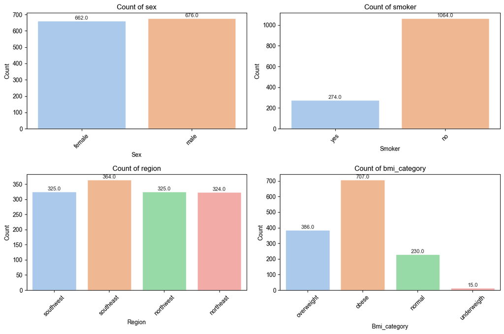

```python
# Countplot

# Set up the plotting grid (2x2)
fig, axes = plt.subplots(2, 2, figsize=(12, 8))
axes = axes.flatten()

# Set Seaborn style
sns.set(style="whitegrid")

# Loop through and create count plots
for i, col in enumerate(cats):
    ax = axes[i]
    plot = sns.countplot(x=col, data=df, ax=ax, palette='pastel')
    ax.set_title(f'Count of {col}')
    ax.set_xlabel(col.capitalize())
    ax.set_ylabel('Count')
    ax.tick_params(axis='x', rotation=45)

    # Add count labels on top of bars
    for p in plot.patches:
        height = p.get_height()
        ax.annotate(f'{height}', (p.get_x() + p.get_width() / 2., height),
                    ha='center', va='bottom', fontsize=9)

plt.tight_layout()
plt.show()
```

**Gender Distribution**: The dataset shows an equal distribution of gender, with males representing approximately 50.5% of the total records, and female represents 49.5%.

**Smoking Status**: There are significantly more non-smokers than smokers in the dataset. However, this variable is of particular interest because smoking is a known risk factor for numerous health issues, and it’s likely to have a strong impact on medical charges.

**Regional Representation**: The dataset is relatively balanced across the four U.S. regions (northeast, southeast, southwest, northwest), although the southeast appears to have a slightly higher count. This regional variation might be useful when examining geographical cost differences in insurance.

**BMI Classification**: Most individuals fall under the "overweight" or "obese" categories, with fewer in the "underweight" and "normal" groups. Given that higher BMI is linked to health risks, it will be interesting to examine how medical charges scale across these categories.

# *Numerical Data Analysis*

```python
#Describing numerical values

df[nums].describe()
```

|  | age | bmi | children | charges |
| --- | --- | --- | --- | --- |
| count | 1338.000000 | 1338.000000 | 1338.000000 | 1338.000000 |
| mean | 39.207025 | 30.663397 | 1.094918 | 13270.422265 |
| std | 14.049960 | 6.098187 | 1.205493 | 12110.011237 |
| min | 18.000000 | 15.960000 | 0.000000 | 1121.873900 |
| 25% | 27.000000 | 26.296250 | 0.000000 | 4740.287150 |
| 50% | 39.000000 | 30.400000 | 1.000000 | 9382.033000 |
| 75% | 51.000000 | 34.693750 | 2.000000 | 16639.912515 |
| max | 64.000000 | 53.130000 | 5.000000 | 63770.428010 |

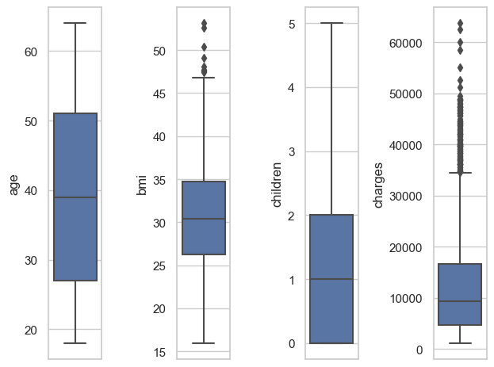

```python
##Box Plot
for i in range(0, len(nums)):
    plt.subplot(1, len(nums), i + 1)
    sns.boxplot(y = df[nums[i]])
    plt.tight_layout()
```

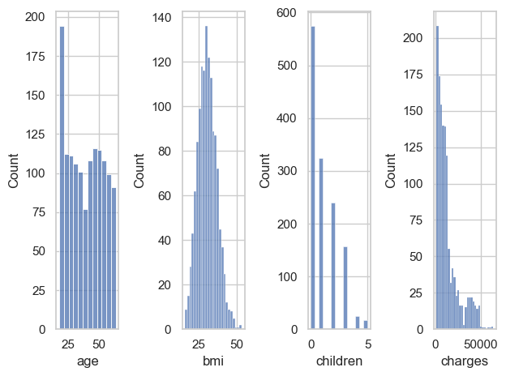

```python
#Histplot

for i in range(0, len(nums)):
    plt.subplot(1, len(nums), i +1)
    sns.histplot(data = df[nums[i]])
    plt.tight_layout()
```

**BMI (Body Mass Index)**: The average BMI is 30.66, which is at the borderline of the Obese category. The BMI values range from 15.96 (underweight) to 53.13 (morbidly obese). 75% of the individuals have a BMI below 34.69, suggesting a significant proportion may still be overweight or obese.

**Insurance Charges:**

[output not shown]

**Age:** The average age of the population is 39, with a minimum age of 18 and a maximum of 64. This indicates that the dataset primarily includes adults, excluding younger individuals who are likely covered under their parents' health plans, and seniors aged 65 and above who are typically enrolled in government-sponsored health plans

**Children:** On average, people have 1 child, with the majority having between 0 and 2 children. Only a small number of individuals have 3 to 5 children

**Visual Analysis**

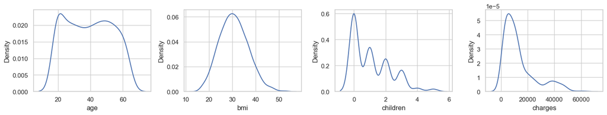

```python
##Kernel Density Estimate

plt.figure(figsize=(15, 3))
for i in range(0, len(nums)):
    plt.subplot(1, len(nums), i + 1)
    sns.kdeplot(x = df[nums[i]])
    plt.tight_layout()
```

# *Correlation Analysis*

```python
#Finding correlation for numerical values using pearson correlation
```

```
               age       bmi  children   charges
age       1.000000  0.109272  0.042469  0.299008
bmi       0.109272  1.000000  0.012759  0.198341
children  0.042469  0.012759  1.000000  0.067998
charges   0.299008  0.198341  0.067998  1.000000
```

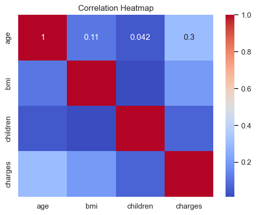

```python
print (df[['age', 'bmi', 'children', 'charges']].corr())

sns.heatmap(df[['age', 'bmi', 'children', 'charges']].corr(), annot=True, cmap='coolwarm')
plt.title("Correlation Heatmap")
plt.show()
```

**Age vs. Charges (Correlation: 0.3)**: There is a moderate positive correlation between age and charges. As age increases, medical insurance charges tend to rise, likely due to higher healthcare needs in older age groups.

**Children vs. Charges (Correlation: 0.06)**: The number of children has a very weak correlation with charges. The presence of children does not strongly affect medical insurance costs in this dataset.

# Analyzing the data:

The first and most crucial step in any data science project is defining the right business question. What insights can this dataset offer that will create tangible value for the insurance industry?

In this project, we analyze a medical insurance dataset that includes customer attributes such as age, BMI, and smoking status—all key variables that influence individual health risks and, consequently, insurance charges. From a business perspective, we hypothesize that these factors are strong predictors of medical costs and should directly inform premium pricing and risk segmentation strategies.

**Business Objective**

Our goal is to equip insurance providers with actionable insights that will enable smarter pricing models, customer segmentation, and preventive care strategies. By identifying the characteristics of high-cost individuals, insurers can better manage financial risk and allocate resources more efficiently.

**Key Business Questions**

1. What are the primary cost drivers for medical insurance claims?
2. Which customer segments pose the highest financial risk to insurers?
3. How does smoking status influence insurance costs?
4. How do combined risk factors—like age, BMI, and smoking—amplify insurance costs?

Beyond identifying cost trends, this analysis aims to support strategic product design, targeted customer acquisition, and health intervention planning—all of which contribute to delivering customer value, improving population health, and increasing operational efficiency for insurers.

**Effect of Age on Medical Insurance**:

```python
# Updated bins and labels for 18–30, 31–54, 55–64
age_bins = [18, 31, 55, 65]  # 18–30, 31–54, 55–64 (65 is exclusive upper bound)
age_labels = ['18–30', '31–54', '55–64']     # 18-30  adults, 30-54 elary to mid professional life,
                                          #55+ is near Retirement

# Create a new column for age group
df['age_group'] = pd.cut(df['age'], bins=age_bins, labels=age_labels, right=False)

# Group by age group and calculate the average charges
avg_charges_by_age_group = df.groupby('age_group')['charges'].mean().round(2).reset_index()

# Display count of records in each age group
print(df.groupby("age_group")["age"].count())

# Display average charges by age group
print(avg_charges_by_age_group)
```

```
age_group
18–30    444
31–54    652
55–64    242
Name: age, dtype: int64
  age_group   charges
0     18–30   9397.55
1     31–54  13961.81
2     55–64  18513.28
```

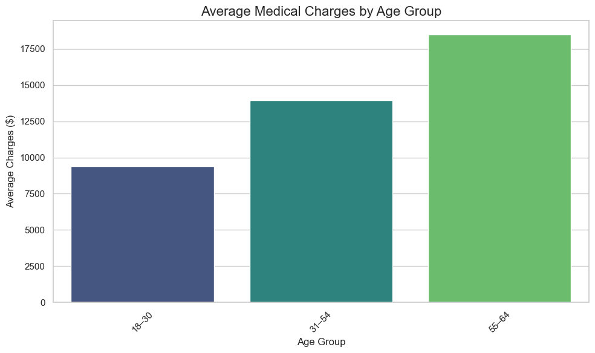

```python
#Plot the result using Seaborn
plt.figure(figsize=(10, 6))  # Set figure size
sns.barplot(x='age_group', y='charges', data=avg_charges_by_age_group, palette='viridis')

# Customize the plot
plt.title('Average Medical Charges by Age Group', fontsize=16)
plt.xlabel('Age Group', fontsize=12)
plt.ylabel('Average Charges ($)', fontsize=12)
plt.xticks(rotation=45)
plt.tight_layout()
```

```python
avg_charges_by_age_group['increase_in_cost'] = avg_charges_by_age_group['charges'].diff().round(2)

avg_charges_by_age_group['percent_increase'] = ((avg_charges_by_age_group['increase_in_cost'] / avg_charges_by_age_group['charges'].shift(1)) * 100).round(2)

print(avg_charges_by_age_group)
```

```
  age_group   charges  increase_in_cost  percent_increase
0     18–30   9397.55               NaN               NaN
1     31–54  13961.81           4564.26             48.57
2     55–64  18513.28           4551.47             32.60
```

As individuals transition from young adulthood into middle age, medical insurance charges increase notably. The data shows that average charges rise from $9397 for those aged 18 to 30, to $13,961 for the 31 to 54 group a 48.5% increase. This jump reflects not just age-related health risks, but also significant lifestyle shifts. People in this age range are often in their prime working years, starting families, getting married, and raising children, all of which contribute to greater health care usage. Maternity care, pediatric visits, and increased preventive services are more common, raising overall medical expenses.

Costs rise even further in the 55 to 64 age group, reaching an average of $18,513 an additional 32.6% increase. This stage typically brings more chronic conditions, age-related diseases, and higher hospitalization rates, significantly impacting insurance costs.

These insights highlight a clear age-based progression in health care expenses. As individuals age, both their health care needs and unpredictability of medical costs grow. For insurers and policymakers, this underlines the importance of age-adjusted insurance models, early intervention, and wellness programs to manage risk and support healthier aging.

```python
# Step 3: Group by age group and smoker status, calculate average charges
grouped = df.groupby(['age_group', 'smoker'])['charges'].mean().reset_index()

# Step 4: Pivot for better readability (optional)
pivot = grouped.pivot(index='age_group', columns='smoker', values='charges').reset_index()

# Step 5: Display result
print(pivot)
```

```
smoker age_group            no           yes
0          18–30   4462.308505  27528.078343
1          31–54   8939.320975  32841.961539
2          55–64  14064.827492  39696.365439
```

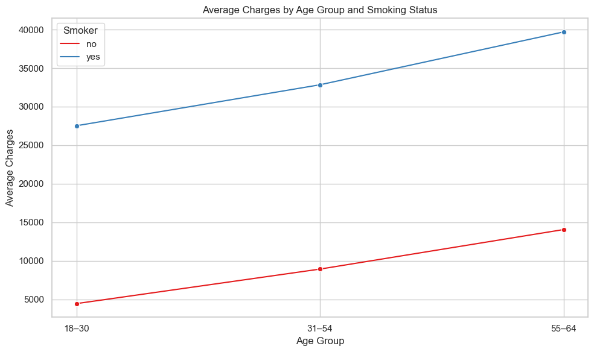

```python
plt.figure(figsize=(10, 6))
sns.lineplot(data=grouped, x='age_group', y='charges', hue='smoker', marker='o', palette='Set1')


#chart
plt.title('Average Charges by Age Group and Smoking Status')
plt.xlabel('Age Group')
plt.ylabel('Average Charges')
plt.legend(title='Smoker')
plt.tight_layout()
plt.show()
```

The visualizations clearly show that within each age group, individuals who smoke consistently incur significantly higher average medical charges compared to non-smokers. This pattern remains consistent across all age brackets, highlighting the financial burden associated with smoking-related health risks.

On average, the difference in charges between smokers and non-smokers in each group ranges from $23,000 to $25,000, underscoring the substantial cost impact of smoking. These elevated charges are likely driven by the increased incidence of chronic conditions linked to smoking—such as cancer, cardiovascular disease, respiratory illnesses like asthma, and other long-term complications.

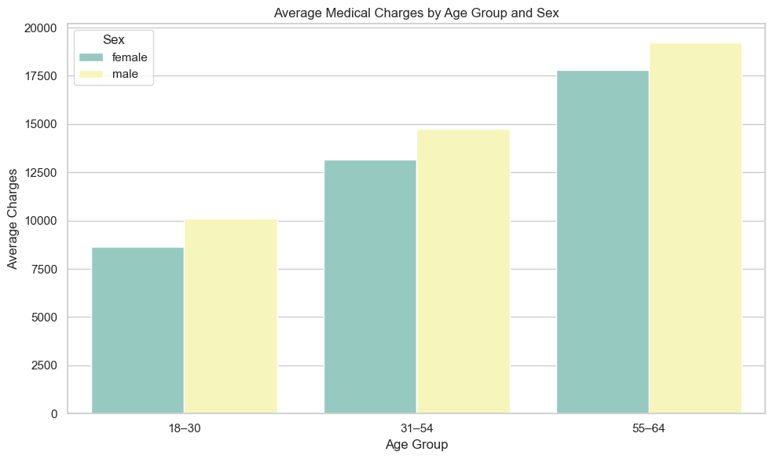

```python
#Group by age group and sex, calculate average charges
sex_grouped = df.groupby(['age_group', 'sex'])['charges'].mean().reset_index()

plt.figure(figsize=(10, 6))
sns.barplot(data=sex_grouped, x='age_group', y='charges', hue='sex', palette='Set3')



# Chart formatting
plt.title('Average Medical Charges by Age Group and Sex')
plt.xlabel('Age Group')
plt.ylabel('Average Charges')
plt.legend(title='Sex')
plt.tight_layout()
plt.show()
```

The visualization indicates that within each age group, there is no significant difference in average medical charges between males and females. However, a slight trend can be observed where males tend to incur higher average charges than females across most age groups.

This pattern suggests the need for deeper analysis to understand the underlying factors. Possible reasons could include differences in lifestyle, occupation-related risks, or the prevalence of certain medical conditions among males that drive up healthcare costs.

**Effects of BMI in health Insurance**

```
(0.0, 66902.8557155)
```

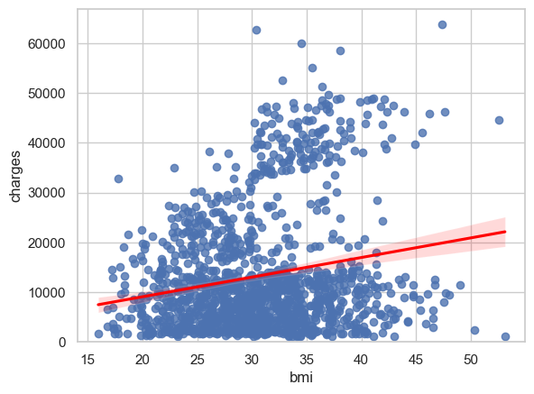

```python
#Regression plot:

sns.regplot(x='bmi', y='charges', data=df, line_kws={'color': 'red'})
plt.ylim(0,)
```

**Summary of Regression Plot**: The regression plot shows a positive correlation between BMI and charges, indicating that higher BMI tends to be associated with higher charges. However, the relationship is weak, as indicated by the wide scatter of data points around the regression line. The plot also highlights potential outliers and suggests that other factors may influence charges, necessitating further investigation and potentially more complex approaches.

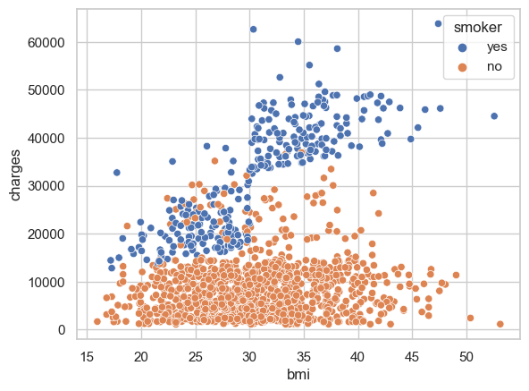

```python
sns.scatterplot(x = 'bmi', y = 'charges', hue = 'smoker', data = df)
```

A person who smoke and have a BMI above 30 tends to have a higer cost

```python
# Group by bmi_category and calculate average charges
bmi_avg_charges = df.groupby('bmi_category')['charges'].mean().reset_index().sort_values(by='charges', ascending=False).round(2)

# Display results
print(bmi_avg_charges)
```

```
  bmi_category   charges
1        obese  15552.34
2   overweight  10987.51
0       normal  10458.69
3  underweigth   7576.42
```

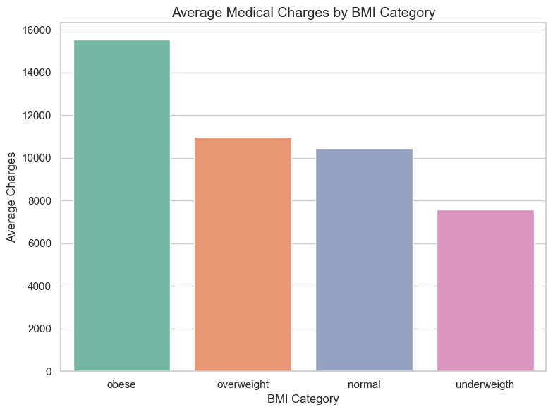

```python
# Plot
plt.figure(figsize=(8, 6))
ax = sns.barplot(data=bmi_avg_charges, x='bmi_category', y='charges', palette='Set2')



plt.title('Average Medical Charges by BMI Category', fontsize=14)
plt.xlabel('BMI Category')
plt.ylabel('Average Charges')
plt.tight_layout()
plt.show()
```

From the visualization, we observe that individuals in the obese BMI category tend to incur higher average medical charges compared to those in the normal weight range. This is consistent with medical research, as obesity is commonly linked to chronic health conditions such as heart disease, diabetes, and hypertension, all of which can lead to increased medical interventions and costs.

In contrast, individuals categorized as underweight appear to have lower average medical expenses. However, the limited number of data points in this category suggests that this average may not accurately reflect the broader population. Underweight individuals can also experience significant health issues, including malnutrition, osteoporosis, and a weakened immune system, which may increase healthcare needs if observed in a larger dataset.

Because insurance companies base premiums on the expected cost of care, individuals with higher health risks (such as those with extreme BMIs) often face higher life or health insurance premiums. In other words, the more a person is statistically likely to need medical services due to their weight-related health risks, the more they may be charged for insurance coverage. Understanding this relationship can help individuals make informed decisions about their health and financial planning.

**Effects of Smokers vs Non Smokers in heath insurance**

```
  smoker       charges
0     no   8434.268298
1    yes  32050.231832
smoker
no     1064
yes     274
Name: count, dtype: int64
```

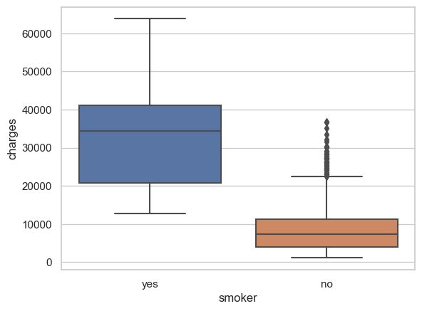

```python
print(df.groupby("smoker")["charges"].mean().reset_index())
print(df["smoker"].value_counts())


sns.boxplot(x='smoker', y='charges', data=df)
```

Although smokers make up only about 20% of the dataset, their average insurance charges are significantly higher than those of non-smokers. Notably, even the minimum charges for smokers are often higher than the upper quartile of charges for non-smokers. This indicates a consistent trend where individuals who smoke tend to incur substantially greater medical expenses, likely due to smoking-related health risks. This pattern reinforces the strong correlation between smoking and elevated healthcare costs.

```python
#Customer segmentation Analysis
```

```python
# Group by age group, BMI group, and smoker
segmentation = df.groupby(['age_group', 'bmi_category', 'smoker'])['charges'].mean().reset_index()
segmentation = segmentation.sort_values(by='charges', ascending=False)
segmentation
```

|  | age_group | bmi_category | smoker | charges |
| --- | --- | --- | --- | --- |
| 19 | 55–64 | obese | yes | 46979.922500 |
| 11 | 31–54 | obese | yes | 42803.402432 |
| 3 | 18–30 | obese | yes | 36901.885133 |
| 15 | 31–54 | underweigth | yes | 32734.186300 |
| 21 | 55–64 | overweight | yes | 28642.792333 |
| 17 | 55–64 | normal | yes | 25513.963863 |
| 13 | 31–54 | overweight | yes | 23213.173535 |
| 9 | 31–54 | normal | yes | 21085.825982 |
| 5 | 18–30 | overweight | yes | 18483.750371 |
| 1 | 18–30 | normal | yes | 16810.535175 |
| 18 | 55–64 | obese | no | 14310.254851 |
| 7 | 18–30 | underweigth | yes | 14097.226200 |
| 20 | 55–64 | overweight | no | 13690.084303 |
| 16 | 55–64 | normal | no | 13686.251035 |
| 10 | 31–54 | obese | no | 9098.649522 |
| 8 | 31–54 | normal | no | 9021.981289 |
| 12 | 31–54 | overweight | no | 8678.275649 |
| 14 | 31–54 | underweigth | no | 6211.675117 |
| 0 | 18–30 | normal | no | 4521.809640 |
| 2 | 18–30 | obese | no | 4516.089603 |
| 4 | 18–30 | overweight | no | 4484.591644 |
| 6 | 18–30 | underweigth | no | 2498.176625 |
| 22 | 55–64 | underweigth | no | NaN |
| 23 | 55–64 | underweigth | yes | NaN |

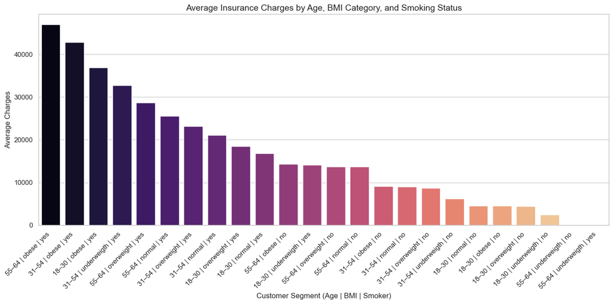

```python
# Group by age, BMI, and smoker status
grouped = df.groupby(['age_group', 'bmi_category', 'smoker'])['charges'].mean().reset_index()
grouped['charges'] = grouped['charges'].round(2)

# Combine categories for easier plotting
grouped['segment'] = grouped['age_group'].astype(str) + ' | ' + grouped['bmi_category'].astype(str) + ' | ' + grouped['smoker']

# Sort by charges in descending order
grouped = grouped.sort_values(by='charges', ascending=False)

# Plot
plt.figure(figsize=(14, 7))
sns.barplot(x='segment', y='charges', data=grouped, palette='magma')

plt.title('Average Insurance Charges by Age, BMI Category, and Smoking Status', fontsize=14)
plt.ylabel('Average Charges')
plt.xlabel('Customer Segment (Age | BMI | Smoker)')
plt.xticks(rotation=45, ha='right')
plt.tight_layout()
plt.show()
```

The visualization and segmentation analysis reveal a consistent and important trend: individuals who smoke consistently incur higher average medical charges across all age groups. This cost difference becomes even more significant when smoking is combined with a higher BMI, especially within the overweight and obese categories.

Across every age group, smokers tend to pay more than non-smokers—reflecting the increased likelihood of chronic diseases such as heart conditions, lung problems, and cancers associated with tobacco use. When combined with obesity, which is linked to diabetes, hypertension, and cardiovascular issues, the health risks—and therefore medical costs—amplify further.

Notably, the highest average medical charges are observed among individuals in the oldest age group who are both obese and smokers. This segment faces the most compounded health risks, leading to greater medical needs and higher insurance payouts.

These insights are valuable for insurance providers and healthcare planners, as they highlight how the combination of age, smoking, and obesity creates a high-risk profile. Identifying such groups can help guide targeted preventive health programs, policy pricing strategies, and risk management interventions to control healthcare costs while promoting better health outcomes.

# Conclusion

This analysis provides a data-driven understanding of the key factors influencing individual medical insurance charges. Through exploratory and statistical analysis, we identified clear patterns and correlations between customer characteristics and healthcare costs.

1. **Primary Cost Drivers for Medical Insurance Claims** The key cost drivers for medical insurance claims are age, BMI, and smoking status. As individuals age, they are more likely to experience health issues, leading to increased medical expenses. Similarly, individuals with higher BMI are at greater risk for chronic conditions, such as cardiovascular diseases and diabetes, which drive up healthcare costs. Smokers, due to the higher incidence of smoking-related illnesses, contribute significantly to elevated insurance claims.
2. **Customer Segments Posing the Highest Financial Risk to Insurers** The highest-risk customer segments include individuals over the age of 50, smokers, and those classified as having a high BMI. These groups are more likely to face serious health issues, leading to higher medical expenses and making them costly for insurers to cover. Interestingly, individuals in the underweight category tend to have lower average charges. While underweight status can also be associated with certain health risks, this may not be strongly reflected in the current dataset—possibly due to a smaller sample size within that category.
3. **Impact of Smoking Status on Insurance Costs** Smoking status is a critical determinant of medical insurance costs. Smokers typically incur higher medical expenses due to the elevated risk of smoking-related diseases, such as heart disease, stroke, and lung cancer. This higher risk leads to increased claims and, consequently, higher premiums for smokers.
4. **Amplification of Insurance Costs by Combined Risk Factors** The combination of age, high BMI, and smoking status further intensifies the financial burden on insurance providers. Each of these factors individually increases the likelihood of significant health issues, and when combined, they compound the risk of severe health problems. This results in a higher frequency of medical claims and a considerable increase in insurance costs.

**How Insurers Can Use These Insights:**

**Risk Profiling**: Insurers can use these insights to develop more accurate risk models and set premiums accordingly, ensuring financial sustainability while maintaining fairness.

**Customer Segmentation**: By classifying policyholders based on their risk levels, insurers can tailor product offerings, adjust coverage levels, or suggest preventative health interventions.

**Possible Next Steps:**

**Build a Predictive Model**: Using regression or machine learning algorithms to predict individual insurance charges based on personal and lifestyle attributes.

**Explore Temporal Trends**: If time-series data becomes available, analyzing changes over time can help detect emerging risks or evaluate the effectiveness of interventions.